# Basic Portfolio Analysis in Python

## Portfolio versus fund versus index

- **Portfolio:** a collection of investments (stocks, bonds, commodities, other funds) often owned by an individual.
- **Fund:** A pool of investments that is managed by a professional fund manager. Individual investors buy "*units*" of the fund and the manager invests the money.
- **Index:** A smaller sample of the market that is representative of the whole, e.g. **S&P500**, **Nasdaq**, **Russell 2000**, **MSCI World Index**.

### Active versus passive investing

- **Passive investing:** following a benchmark as closely as possible
- **Active investing:** taking active "bets" that are different from a benchmark
- **Long only strategies:** small deviations from a benchmark
- **Hedgefunds:** no benchmark but 'total return strategies'

#### Typical portfolio strategies

- Equal weighted portfolios
- Market-cap weighted portfolios
- Risk-return optimized portfolios

[figure not shown]

# The effect of diversification

We're going to compare performance of four individual stocks, to a portfolio of the same four stocks. We'll see that $2$ out of the four stocks will under-perform over a time period of roughly four years, and two will perform quite well.

The stocks we're going to investigate are **General Electric**, **JP Morgan**, **Microsoft** and **Proctor & Gamble**.

Let's play a little game: pick one stock to invest in, then, let's see how it would have performed over time. There's a $50-50$ chance that we'll pick a winning stock, versus a losing stock. Let's look at the data and see whether our stock is one of strong performers.

```python
import pandas as pd

stock_returns = pd.read_csv('https://assets.datacamp.com/production/repositories/4745/datasets/da4863e3ea40482a56929e595f1a7c6e1fdaf614/small_portfolio.csv',
                            index_col = 'date').pct_change().dropna()

# Create equal weight portfolio
data = stock_returns.copy()
data /= len(data.columns)
stock_returns['portfolio'] = data.sum(axis=1)

# Check beginning and end of dataset
print(stock_returns.head())
print('\n',stock_returns.tail())
```

```
                  GE       JPM      MSFT        PG  portfolio
date
2015-01-05 -0.018356 -0.031045 -0.009303 -0.004755  -0.015865
2015-01-06 -0.021545 -0.025929 -0.014571 -0.004555  -0.016650
2015-01-07  0.000415  0.001526  0.012705  0.005246   0.004973
2015-01-08  0.012043  0.022346  0.029418  0.011436   0.018811
2015-01-09 -0.013952 -0.017387 -0.008405 -0.009330  -0.012269

                   GE       JPM      MSFT        PG  portfolio
date
2018-03-21  0.017595  0.000872 -0.006979 -0.016218  -0.001182
2018-03-22 -0.038184 -0.041747 -0.029087 -0.008178  -0.029299
2018-03-23 -0.020974 -0.026739 -0.029068 -0.006544  -0.020831
2018-03-26 -0.013772  0.030838  0.075705  0.006587   0.024840
2018-03-27  0.042669 -0.019400 -0.045959  0.018060  -0.001157
```

#### Function to plot returns

```python
import matplotlib
import matplotlib.pyplot as plt

def plot_pct_returns(df, xs = 8, ys = 6):
    fig, ax = plt.subplots(figsize=(xs,ys))
    ax.plot(df.index, df.MSFT, marker='', color='green', linewidth=2, label="MSFT")
    ax.plot(df.index, df.portfolio, linewidth=2, linestyle='dashed', color='skyblue', label='portfolio')
    ax.plot(df.index, df.PG, marker='', color='pink', linewidth=2, label="PG")
    ax.plot(df.index, df.JPM, color='yellow', linewidth=2, label='JPM')
    ax.plot(df.index, df.GE, color='red', linewidth=2, label='GE')
    ax.xaxis.set_major_locator(matplotlib.dates.YearLocator())
    ax.xaxis.set_major_formatter(matplotlib.dates.DateFormatter("\n%Y"))
    plt.setp(ax.get_xticklabels(), rotation=0, ha="center")
    plt.legend()
    plt.show()
```

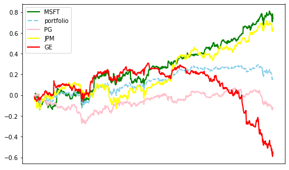

```python
# Plot percentage returns
plot_pct_returns(stock_returns.cumsum(), xs = 8, ys = 5)
```

# Portfolio returns

## What are portfolio weights?

- Weight is the percentage composition of a particular asset in a portfolio
- All weights together have to sum up to $100\%$
- Weights and diversification (few large investments versus many small investments)

### Calculating portfolio weights

- Calculate by dividing the value of a security by total value of the portfolio
- Equal weighted portfolio, or market cap weighted portfolio
- Weights determine your investment strategy, and can be set to optimize risk and expected return

$$ Weight = \frac{Stock's \: value}{Total \: portfolio \: value} \times 100 $$

#### Portfolio returns

$$ Return_t = \frac{V_t - V_{t-1}}{V_{t-1}} $$

- Changes in value over time
- Historic average returns often used to calculate **expected** return
- Warning for confusion: average return, cumulative return, active return, and annualized return

# Calculate mean returns

```python
data = pd.read_csv('https://assets.datacamp.com/production/repositories/4745/datasets/da4863e3ea40482a56929e595f1a7c6e1fdaf614/small_portfolio.csv',
                            index_col = 'date')

# Calculate percentage returns
returns = data.pct_change().dropna()

# Calculate individual mean returns
meanDailyReturns = returns.mean()

# Define weights for the portfolio
weights = np.array([0.5, 0.2, 0.2, 0.1])

# Calculate expected portfolio performance
portReturn = np.sum(meanDailyReturns*weights)

# Print the portfolio return
print(portReturn)
```

```
-1.6782226618545547e-05
```

## Portfolio cumulative returns

We've calculated the **mean performance** over a period of time. This gives us **one performance number** for that entire period. But what if we wanted to plot the development of the performance over time? For that, we will need the **cumulative performance**, not the mean performance. Just like with interest in your bank account, the cumulative performance gives you the **compounded return** at each date in your dataset. It tells you; "up until today, this is what the total return has been since the start of my data."

Because of the compounding effect, we will need to use `cumprod()` for this calculation.

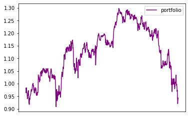

```python
# Create portfolio returns column
returns['Portfolio'] = returns.dot(weights)

# Calculate cumulative returns
daily_cum_ret=(1+returns).cumprod()

# Plot the portfolio cumulative returns only
fig, ax = plt.subplots()
ax.plot(daily_cum_ret.index, daily_cum_ret.Portfolio, color='purple', label="portfolio")
ax.xaxis.set_major_locator(matplotlib.dates.YearLocator())
plt.legend()
plt.show()
```

# Measuring risk of a portfolio

## Risk of a portfolio

- Investing is risky: individual assets will go up or down
- The **expected** return is a random variable
- Returns spread around the mean and is measured by the variance $\sigma^2$ and is a common measure of volatility

$$ \sigma^2 = \frac{\sum\limits_{i=1}^{N} (X - \mu)^2}{N} $$

### Variance

- Variance of an individual asset varies: some have more or less spread around the mean
- Variance of the portfolio is not simply the weighted variances of the underlying assets
- Because returns of assets are correlated, it becomes complex

#### How do variance and correlation relate to portfolio risk?

- The **correlation** between asset $1$ and $2$ is denoted by $p_{1,2}$ , and tells us to which extend assets move together
- The **portfolio variance** takes into account the individual assets' **variances** ( $\sigma_1^2$ , $\sigma_2^2$ , etc ), the **weights** of the assets in the portfolio ( $w_1$ , $w_2$ ), as well as their **correlation** to each other
- The **standard deviation** ( $\sigma$ ) is equal to the square root of variance ( $\sigma^2$ ), both are a measure of volatility

#### Calculating portfolio variance

$$ \sigma_{pf}^2 = w_1^2 \sigma_1^2 + w_2^2 \sigma_2^2 + w_1 w_2 p_{1,2} \sigma_{1} \sigma_{2} $$

- $ρ_{1,2} σ_1 σ_2$ is called the covariance between asset $1$ and $2$
- The covariance can also be written as $σ_{1,2}$
- This let's us write:

$$ \sigma_{pf}^2 = w_1^2 \sigma_1^2 + w_2^2 \sigma_2^2 + 2 w_1 w_2 \sigma_{1,2} $$

#### Re-writing the portfolio variance shorter

$$ \sigma_{pf}^2 = w_2^1 \sigma_2^2 + 2 w_1 w_2 \sigma_{1,2} + w_2^2 \sigma_2^2 $$

- This can be re-written in **matrix notation**, which you can use more easily in code:

$$ \sigma_{pf}^2 = [w_1 \: w_2] \begin{bmatrix} \sigma_1^2 & \sigma_{1,2} \\ \sigma_{2,1} & \sigma_2^2 \end{bmatrix} \begin{bmatrix} w_1 \\ w_2 \end{bmatrix} $$

- In words, what we need to calculate in python is: Portfolio variance = Weights transposed $\times$ (Covariance matrix $\times$ Weights)

# Portfolio variance

It's time to calculate the risk of our $4$-stock portfolio. Let's start with the pricing data. We'll have to calculate daily percentage returns and assign weights to our portfolio. We'll then continue by calculating the covariance matrix, and use the following formula: Portfolio variance = Weights transposed $\times$ (Covariance matrix $\times$ Weights) to get the final portfolio variance.

```python
# Get percentage daily returns
daily_returns = data.pct_change().dropna()

# Assign portfolio weights
weights = np.array([0.05, 0.4, 0.3, 0.25])

# Calculate the covariance matrix
cov_matrix = (daily_returns.cov())*250

# Calculate the portfolio variance
port_variance = np.dot(weights.T, np.dot(cov_matrix, weights))

# Print the result
print(str(np.round(port_variance, 4) * 100) + '%')
```

```
2.55%
```

## Looking at our covariance matrix

The variances of the stocks are in the diagonal of the covariance matrix. The variance tell us how much the returns of individual stocks deviate from their mean.

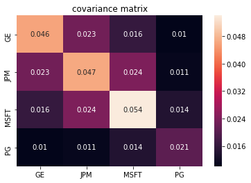

```python
import seaborn as sns

sns.heatmap(cov_matrix, annot=True)
b, t = plt.ylim()
b += 0.5
t -= 0.5
plt.ylim(b, t)
plt.title('covariance matrix')
plt.show()
```

Microsoft is the riskiest, since it's variance is $5.4\%$, which is the highest of all the stocks in the portfolio.

# Standard deviation versus variance

Let's talk about the difference between *variance* and *standard deviation*. We already know that the standard deviation $\sigma$ is simply the square root of the variance. Both measures are used in practice to calculate market or stock volatility. Why should you use one or the other?

In the variance calculation we **square** the weights and the variances. Because of this squaring, the variance is **no longer in the same unit** of measurement as the original data. Taking the **root of the variance** means the standard deviation is **restored** to the original unit of measure and therefore much easier to interpret. Let's calculate the standard deviation.

```python
# Calculate the standard deviation by taking the square root
port_standard_dev = np.sqrt(np.dot(weights.T, np.dot(weights, cov_matrix)))

# Print the results
print(str(np.round(port_standard_dev, 4) * 100) + '%')
```

```
15.959999999999999%
```

The standard deviation tells you how much the portfolio's return can deviate from the mean historical return. If a portfolio has a $12\%$ average rate of return and a standard deviation of $4\%$, its return will range from $8-16\%$. The mean historic return of this particular portfolio is actually close to zero. With an average standard deviation of roughly $16\%$, this means you're getting a bad deal here!

# Calculating returns

## Comparing returns

1. **Annual Return:** Total return earned over a period of one calendar year
2. **Annualized return:** Yearly rate of return inferred from any time period
3. **Average Return:** Total return realized over a longer period, spread out evenly over the (shorter) periods.
4. **Cumulative (*compounding*) return:** A return that includes the compounded results of re-investing interest, dividends, and capital gains.

### Calculating annualized returns

- $N$ in years: $$ rate = (1 + Return)^{1/N} − 1 $$
- $N$ in months: $$ rate = (1 + Return)^{12/N} − 1 $$
- $N$ in days: $$ rate = (1 + Return)^{365/N} − 1 $$
- Convert any time length to an annual rate:
  - **Return** is the total return you want to annualize.
  - $N$ is number of periods so far.

# Annualizing portfolio returns

Suppose you invested $\$101$ at the beginning of **2015** in a portfolio. By the end of **March** **2018**, you wonder how your portfolio has performed over time, and whether it is as good as another portfolio which started trading **mid-2016**. What performance metric do you look at? Well, the annualized return of course!

So let's calculate the annualized rate of return for your portfolio. Since our sample covers $3.2$ years, let's use the monthly denomination in the formula for annualized returns. The number of months is given under `months`.

The data on portfolio returns is under `pf_returns`, as well as as a separate series `pf_AUM` containing the portfolio's value, or assets under management (AUM).

```python
# Define weights for a better portfolio
weights = np.array([0.0, 0.5, 0.5, 0.0, 0.0])

# Create better portfolio returns column
returns['Portfolio'] = returns.dot(weights)

# Calculate the effect of our better portfolio selection on a hypothetical $101 investment
cash = 101
port_cash = [cash]  # set starting cash amounts
for r in returns.Portfolio:
    cash *= (1 + r)
    port_cash.append(cash)

pf_AUM = pd.Series(port_cash)
pf_returns = pd.Series(returns.Portfolio)

# Calculate the total number of months for the portfolio's return
returns.index = pd.to_datetime(returns.index)
months = int(((returns.index[-1] - returns.index[0])/np.timedelta64(1, 'M')))
print(f'Portfolio\'s # of months: {months}')

# Calculate total rate of return from start to end
total_return = (pf_AUM.iloc[-1] - pf_AUM.iloc[0]) / pf_AUM.iloc[0]
print(f'\nPortfolio\'s total return: {total_return}')

# Annualize return
annualized_return = ((1 + total_return)**(12/months))-1
print(f'\nPortfolio\'s annualized return: {annualized_return}')
```

```
Portfolio's # of months: 38

Portfolio's total return: 0.8586106763811118

Portfolio's annualized return: 0.21620524453808398
```

## Comparing annualized rates of return

Previously we saw that the annualized rate of return was $21.6\%$. That's pretty high! But since our portfolio consists of only $4$ stocks, this high return is indeed possible as it is not very diversified. Let's compare the portfolio's annual rate of return, with that of the **S&P500**, which is much more diversified.

```python
sp500_value = pd.read_csv('https://assets.datacamp.com/production/repositories/4745/datasets/870eef8aa8b72b4790e12cd3179aa555e1055682/sp500.csv',
                            index_col = 'date')

# Calculate the total number of months for the portfolio's return
sp500_value.index = pd.to_datetime(sp500_value.index)
years = int(((sp500_value.index[-1] - sp500_value.index[0])/np.timedelta64(1, 'Y')))
print(f'S&P500\'s # of years: {years}')

# Calculate total rate of return from start to end
total_return = (sp500_value.iloc[-1] - sp500_value.iloc[0]) / sp500_value.iloc[0]
print(f'\nS&P500\'s total return: {total_return[0]}')

# Annualize return
annualized_return = ((1 + total_return)**(1/years))-1
print(f'\nS&P500\'s annualized return: {annualized_return[0]}')
```

```
S&P500's # of years: 4

S&P500's total return: 0.3762365831481841

S&P500's annualized return: 0.08311176814071208
```

# Risk adjusted returns

- It defines an investment's return by measuring how much risk is involved in producing that return
- It's usually a ratio
- Allows you to objectively compare across different investment options
- Tells you whether the return justifies the underlying risk

## Sharpe ratio

- Sharpe ratio is the most commonly used risk adjusted return ratio
- It's calculated as follows:

$$ \frac{R_p - R_f}{\sigma_p} $$

- Where: $R_p$ is the portfolio return, $R_f$ is the risk free rate and $σ_p$ is the portfolio standard deviation
- Formula for the portfolio $σ_p$

$$ σ_p = \sqrt{(Weights \: transposed(Covariance \: matrix \times Weights))} $$

- A Sharpe ratio of greater than $1$ indicates that the returns on investment are proportional to the risk taken. A Sharpe ratio less than $1$ indicates that return on investment is less than the risk taken. Although there might be other reasons to invest in such a portfolio, the Sharpe ratio doesn't indicate you are getting a great risk-return trade-off.

## Annualizing volatility

- Annualized standard deviation is calculated as follows:

$$σ_a = σ_m \times \sqrt{T}$$

- $σ_m$ is the measured standard deviation
- $σ_a$ is the annualized standard deviation
- $T$ is the number of data points per year
- Alternatively, when using **variance** instead of standard deviation;

$$σ_a^2 = σ_m^2 \times T$$

# S&P500 Sharpe ratio

We're going to calculate the Sharpe ratio of the **S&P500**, starting with pricing data only. Next, we'll do the same for the portfolio data, such that we can compare the Sharpe ratios of the two.

Price data from the **S&P500** is under `sp500_value`. The risk-free rate is under `rfr`, which is conveniently set to zero.

```python
# Calculate total return and annualized return from price data
total_return = (sp500_value.iloc[-1] - sp500_value.iloc[0]) / sp500_value.iloc[0]
print(f'S&P500\'s total return: {total_return[0]}')

# Annualize the total return over 4 year
annualized_return = ((1 + total_return)**(1/4))-1
print(f'\nS&P500\'s annualized return: {annualized_return[0]}')

# Create the returns data
returns_sp500 = sp500_value.pct_change().dropna()

# Calculate annualized volatility from the standard deviation
vol_sp500 = returns_sp500.std() * np.sqrt(250)
print(f'\nS&P500\'s annualized volatility: {vol_sp500[0]}')

# Calculate the Sharpe ratio
rfr = 0.0
sharpe_ratio = ((annualized_return - rfr) /vol_sp500)
print(f'\nS&P500\'s sharpe ratio: {sharpe_ratio[0]}')
```

```
S&P500's total return: 0.3762365831481841

S&P500's annualized return: 0.08311176814071208

S&P500's annualized volatility: 0.1361363458171688

S&P500's sharpe ratio: 0.6105038859521853
```

## Portfolio Sharpe ratio

We are now going to calculate the Sharpe ratio of the portfolio. How do you think the portfolio Sharpe ratio will be different to the **S&P500** Sharpe ratio?

We have the portfolio value over time under `pf_AUM` and the number of months for that data under `months`. Last, the risk-free rate is available under `rfr`, which is still set to zero.

```python
# Calculate total rate of return from start to end
total_return = (pf_AUM.iloc[-1] - pf_AUM.iloc[0]) / pf_AUM.iloc[0]
print(f'Portfolio\'s total return: {total_return}')

# Annualize return
annualized_return = ((1 + total_return)**(12/months))-1
print(f'\nPortfolio\'s annualized return: {annualized_return}')

# Create the returns data
pf_returns = pf_AUM.pct_change()

# Calculate annualized volatility from the standard deviation
vol_pf = pf_returns.std()*np.sqrt(250)
print(f'\nPortfolio\'s annualized volatility: {vol_sp500[0]}')

# Calculate the Sharpe ratio
sharpe_ratio = ((annualized_return - rfr) /vol_pf)
print(f'\nPortfolio\'s sharpe ratio: {sharpe_ratio}')
```

```
Portfolio's total return: 0.8586106763811118

Portfolio's annualized return: 0.21620524453808398

Portfolio's annualized volatility: 0.1361363458171688

Portfolio's sharpe ratio: 1.1202828498295492
```

The small portfolio has a better Sharpe ratio than the **S&P500**. This has to do with the portfolio weights, as those are set to invest most in the best stocks, which, looking back is very easy. Setting the right weights for the future is much harder.

# Non-normal distribution of returns

- In a perfect world returns are distributed normally
- But using mean and standard deviations can be deceiving

## Skewness: leaning towards the negative

[figure not shown]

### Pearson’s Coefficient of Skewness

$$ Skewness = \frac{3(mean − median)}{\sigma} $$

**Rule of thumb:**

- $ Skewness < −1 \: or \: Skewness > 1 \Rightarrow $ Highly skewed distribution
- $ −1 < Skewness < −0.5 \: or \: 0.5 < Skewness < 1 \Rightarrow $ Moderately skewed distribution
- $ −0.5 < Skewness < 0.5 \Rightarrow $ Approximately symmetric distribution

## Kurtosis: Fat tailed distribution

[figure not shown]

**Interpreting kurtosis**

- “Higher kurtosis means more of the variance is the result of infrequent extreme deviations, as opposed to frequent modestly sized deviations.”
- A normal distribution has kurtosis of exactly $3$ and is called (**mesokurtic**)
- A distribution with kurtosis $< 3$ is called **platykurtic**. Tails are shorter and thinner, and central peak is lower and broader.
- A distribution with kurtosis $> 3$ is called **leptokurtic**: Tails are longer and fatter, and central peak is higher and sharper (**fat tailed**)

# Skewness of the S&P500

We already assume that the **S&P500** should be normally distributed, without too much skewness (when you have enough data). However, since we're working with a short data sample spanning only a few years, there might actually be some skewness in our sample. To make you aware of this potential sample skewness, let's plot the data and have a look.

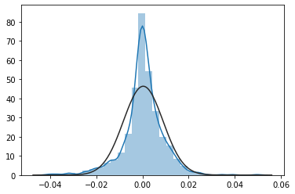

```python
from scipy import stats

# Create a histogram of the S&P500 returns and show the plot
sns.distplot(returns_sp500, norm_hist=True, fit=stats.norm, bins=30)
plt.show()
```

## Calculating skewness and kurtosis

We just saw the histogram of the **S&P500** data, let's now put it into numbers and calculate skewness and kurtosis. For the full picture of the distribution, we'll also look at the mean and standard deviation.

```python
# Print the mean
print("mean : ", returns_sp500.mean()[0]*100)

# Print the standard deviation
print("\nStd. dev  : ", returns_sp500.std()[0]*100)

# Print the skewness
print("\nskew : ", returns_sp500.skew()[0])

# Print the kurtosis
print("\nkurt : ", returns_sp500.kurtosis()[0])
```

```
mean :  0.03389998442910265

Std. dev  :  0.8610018502291797

skew :  -0.38319945187627896

kurt :  3.9223911008585044
```

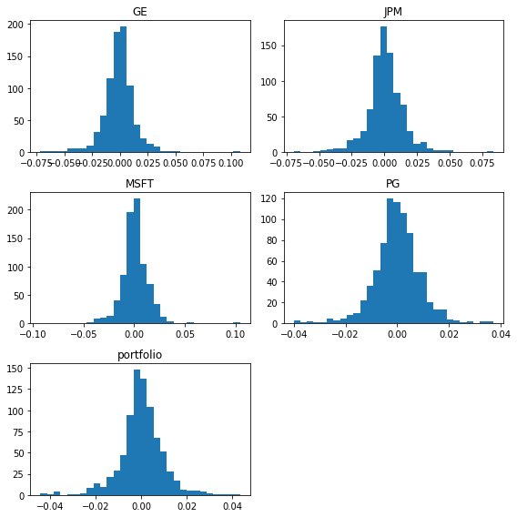

```
skew :
GE           0.177313
JPM          0.018815
MSFT         0.515431
PG          -0.259934
portfolio   -0.240826
dtype: float64

kurt :
GE           7.766370
JPM          3.831448
MSFT         9.882177
PG           2.848092
portfolio    3.582339
dtype: float64
```

```python
# Print the histograms of the stocks in the portfolio
stock_returns.hist(figsize=(8,8), grid=False, bins=30)
plt.tight_layout()
plt.show()

# Print skewness and kurtosis of the stocks
print ('skew :')
print (stock_returns.skew())
print ('\nkurt :')
print (stock_returns.kurtosis())
```

# Alternative measures of risk

## Looking at downside risk

[figure not shown]

### Sortino ratio

- Similar to the Sharpe ratio, just with a different standard deviation.

$$ Sortino Ratio = \frac{R_p − R_f}{\sigma_d} $$

- $σ_d$ is the standard deviation of the downside (negative returns).

$$ Downside \: risk = \sqrt{\frac{1}{N} \sum_{i=1}^n (return - target \: return)^2 f(t)} $$$$ f(t) = 1 \: \text{if return} < \text{target return} $$$$ f(t) = 0 \: \text{if return} \ge \text{target return} $$

### Maximum draw-down

- The largest percentage loss from a market peak to trough
- Dependent on the chosen time window
- The recovery time: time it takes to get back to break-even

# Sortino ratio

Here the portfolio returns data are stored in a DataFrame called `df`, which we'll use to calculate the **Sortino ratio**. The Sortino ratio is just like the Sharpe ratio, except for that it uses the standard deviation of the negative returns only, and thereby focuses more on the downside of investing.

Let's see how big the Sortino ratio is compared to the earlier calculated Sharpe ratio. The risk-free rate `rfr` and the target return `target` are defined as zero.

```python
df = returns.Portfolio.to_frame(name='pf_returns')
rfr = 0
target = 0

# Create a downside return series with the negative returns only
downside_returns = df.loc[df['pf_returns'] < target]

# Calculate expected return and std dev of downside
expected_return = df['pf_returns'].mean()
down_stdev = downside_returns['pf_returns'].std()

# Calculate the sortino ratio
sortino_ratio = (expected_return - rfr)/down_stdev

# Print the results
print("Expected return  : ", expected_return*100)
print("\nDownside risk   : ", down_stdev*100)
print("\nSortino ratio : ", sortino_ratio)
```

```
Expected return  :  0.08380184161454121

Downside risk   :  0.8969860555856709

Sortino ratio :  0.09342602495623448
```

# Maximum draw-down S&P500

Here we'll learn how to calculate the maximum draw-down of the **S&P500** (also known as "peak to trough performance drop"). Maximum draw-down is an incredibly insightful risk measure. It tells you what has been the worst performance of the **S&P500** in the past years.

It is the reason why many investors shy away from crypto-currencies; nobody likes to lose a large percentage of their investment (e.g., $70\%$) in a short period.

In order to calculate the maximum draw-down of the **S&P500**, the daily **S&P500** prices are available in a DataFrame called `df`.

```
Max Daily draw-down: -0.2
```

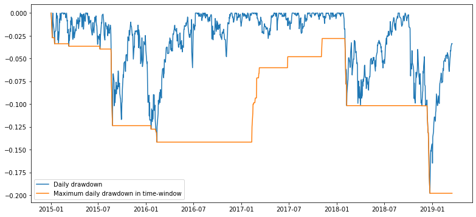

```python
df = sp500_value.copy()
date = df.index

# Calculate the max value
roll_max = df.rolling(center=False,min_periods=1,window=252).max()

# Calculate the daily draw-down relative to the max
daily_draw_down = df/roll_max - 1.0

# Calculate the minimum (negative) daily draw-down
max_daily_draw_down = daily_draw_down.rolling(center=False,min_periods=1,window=252).min()
print(f'Max Daily draw-down: {round(daily_draw_down.min()[0],2)}')

# Plot the results
plt.figure(figsize=(13,6))
plt.plot(date, daily_draw_down, label='Daily drawdown')
plt.plot(date, max_daily_draw_down, label='Maximum daily drawdown in time-window')
plt.legend()
plt.show()
```

# Active investing against a benchmark

[figure not shown]

## Active return for an actively managed portfolio

- Active return is the performance of an (active) investment, **relative** to the investment's benchmark.
- Calculated as the **difference between the benchmark and the actual return**.
- Active return is achieved by "active" investing, i.e. taking **overweight and underweight positions** from the benchmark.

# Active weights

[figure not shown]

### Tracking error for an index tracker

- Passive investment funds, or **index trackers**, don't use active return as a measure for performance.
- **Tracking error** is the name used for the difference in portfolio and benchmark for a **passive** investment fund.

# Active return

Here we're going to calculate the **active return** of a portfolio that's managed against a benchmark. We've learned many ways of how to calculate total return over a period. Now we'll use the simple mean returns multiplied with the weights to obtain a total return for both the portfolio as well as the benchmark. Available is portfolio data containing weights and asset returns under `portfolio_data`.

```python
portfolio_data = pd.read_csv('https://assets.datacamp.com/production/repositories/4745/datasets/f61b6a5210dfa02b8299f96380e500f59cbe38c5/large_pf.csv')

print(portfolio_data.info())

# Calculate return of the portfolio
total_return_pf = (portfolio_data['pf_weights']*portfolio_data['mean_return']).sum()
print(f'\nPortfolio\'s total return: {round(total_return_pf,1)}%')

# Calculate return of the benchmark
total_return_bm = (portfolio_data['bm_weights']*portfolio_data['mean_return']).sum()
print(f'\nBenchmark\'s total return: {round(total_return_bm,1)}%')

# Calculate and print the active return
active_return = total_return_pf - total_return_bm
print(f'\nActive return: {round(active_return,1)}%')
```

```
<class 'pandas.core.frame.DataFrame'>
RangeIndex: 501 entries, 0 to 500
Data columns (total 8 columns):
Unnamed: 0           501 non-null object
mean_return          501 non-null float64
variance             501 non-null float64
pf_weights           501 non-null float64
bm_weights           501 non-null float64
Security             501 non-null object
GICS Sector          501 non-null object
GICS Sub Industry    501 non-null object
dtypes: float64(4), object(4)
memory usage: 31.4+ KB
None

Portfolio's total return: 33.1%

Benchmark's total return: 10.6%

Active return: 22.6%
```

# Industry attribution

Here, we're going to calculate the relative industry position of our portfolio, versus a benchmark. As a portfolio manager you need to understand your portfolio's underweight and overweight positions (or "industry bets"), as they are a large driver of performance, as well as a potential source of risk.

The DataFrame `portfolio_data` contains details about the industry classification, obtained from the Global Industry Classification System or "GICS", of our portfolio holdings, as well as our portfolio weights and the benchmark weights.

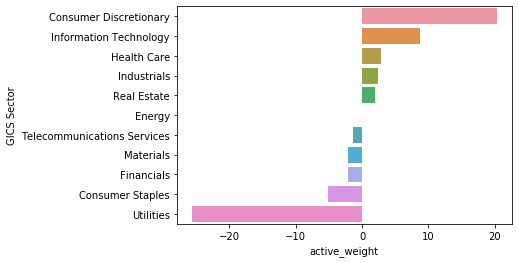

```
Active Weights:
GICS Sector
Consumer Discretionary         20.257
Consumer Staples               -5.176
Energy                          0.000
Financials                     -2.116
Health Care                     2.865
Industrials                     2.465
Information Technology          8.693
Materials                      -2.043
Real Estate                     2.014
Telecommunications Services    -1.367
Utilities                     -25.593
Name: active_weight, dtype: float64
```

```python
# Group dataframe by GICS sectors
grouped_df=portfolio_data.groupby('GICS Sector').sum()

# Calculate active weights of portfolio
grouped_df['active_weight']=grouped_df['pf_weights']-grouped_df['bm_weights']

# Plot active weights of portfolio
g = sns.barplot(y = grouped_df['active_weight'].sort_values(ascending = False).index,
            x = grouped_df['active_weight'].sort_values(ascending = False), orient='h')
plt.show()

print('Active Weights:')
print(grouped_df['active_weight'])
```

# Risk factors

## What is a factor?

- Factors in portfolios are like nutrients in food

[figure not shown]

### Factors in portfolios

- We use factor models to determine risk exposure in our portfolio
- Different types of factors:
  - **Macro factors:** interest rates, currency, country, industry, GDP, trade tariffs, consumer confidence
  - **Style factors:** size, momentum, volatility, value and quality

[figure not shown]

# Momentum factor

Here we are going to investigate the correlation of the **S&P500** returns with 2 factors, **momentum** and **value**.

A stock is showing "momentum" if its prior $12$-month average of returns is positive. The momentum factor is therefore formed by combining stocks that show consistent positive historic returns. The value factor looks at stocks that are inexpensive relative to some measure of fundamental value. For example price-to-earnings and price-to-book are typically ratios to measure "value". Let's see how our **S&P500** returns relate to the returns of these factors.

## Load Data

```python
df = pd.read_csv('https://assets.datacamp.com/production/repositories/4745/datasets/9a9c0ae96a31e2502fb60882eb539c61c0c1230d/pf_factors.csv',
               index_col='date')
df.rename(columns={'WML':'momentum'}, inplace=True)
print(df.info())
df.head()
```

```
<class 'pandas.core.frame.DataFrame'>
Index: 252 entries, 2016-01-04 to 2016-12-30
Data columns (total 4 columns):
S&P500          252 non-null float64
momentum        252 non-null float64
value_factor    252 non-null float64
portfolio       252 non-null float64
dtypes: float64(4)
memory usage: 9.8+ KB
None
```

| date | S&P500 | momentum | value_factor | portfolio |
| --- | --- | --- | --- | --- |
| 2016-01-04 | -1.530373 | -1.69 | -1.53 | -1.651745 |
| 2016-01-05 | 0.201223 | 0.38 | 0.10 | 0.408161 |
| 2016-01-06 | -1.311540 | 1.27 | -1.22 | 0.325555 |
| 2016-01-07 | -2.370044 | 0.21 | -2.38 | -0.698259 |
| 2016-01-08 | -1.083837 | -0.20 | -0.91 | -0.959352 |

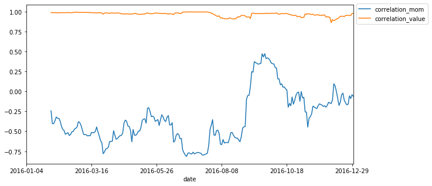

```python
# Calculate 20-day rolling correlation with momentum
df['correlation_mom']=df['S&P500'].rolling(20).corr(df['momentum'])

# Calculate 20-day rolling correlation with value
df['correlation_value']=df['S&P500'].rolling(20).corr(df['value_factor'])

# Plot the correlations
plt.figure(figsize=(10,5))
df['correlation_mom'].plot()
df['correlation_value'].plot()
plt.legend(bbox_to_anchor=(1, 1.025))
plt.show()
```

# Value factor

Previously we looked at the **S&P500** exposures, and saw that there was a large consistent exposure to the value factor, but a very fluctuating correlation to momentum.

Let's now check how our portfolio measures up to this, and let's especially focus on value.

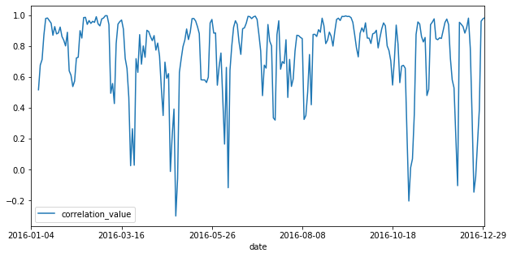

```python
factor_data = pd.DataFrame({'momentum': df['momentum'],
              'value': df['value_factor'],
              'portfolio': df['portfolio']}, index=df.index)

# Calculate the pairwise correlation
factor_data.corr()

# Calculate rolling 5 day correlation
factor_data['correlation_value']=factor_data['portfolio'].rolling(5).corr(factor_data['value'])

# Plot the rolling correlation
plt.figure(figsize=(10,5))
factor_data['correlation_value'].plot()
plt.legend()
plt.show()
```

# Factor models

## Using factors to explain performance

- Factors are used for risk management.
- Factors are used to help explain performance.
- Factor models help you relate factors to portfolio returns
- Empirical factor models exist that have been tested on historic data.
- Fama French $3$ factor model is a well-known factor model.

## Fama French Multi Factor model

$ R_{pf} = \alpha + \beta_mMKT + \beta_sSMB + \beta_hHML $

- Very similar to a multiple linear regression:

$$ Y_{i}=\beta _{0}+\beta _{1}X_{i1}+\beta _{2}X_{i2}+\ldots +\beta _{p}X_{ip}+\epsilon _{i} $$

- The $\beta$ coefficients are the same
- $MKT$ is the excess return of the market, i.e. $R_m − R_f$
- $SMB$ (Small Minus Big) a size factor
- $HML$ (High Minus Low) a value factor

### Difference between beta and correlation

[figure not shown]

# Fama French factor correlations

Here we want to check how much correlation our portfolio returns have with the Fama French factors. With a quick correlation table, we can very easily gain insight into how our portfolio returns move with for example the excess market return or the size and value factors. Remember, the Fama French factor model was defined as follows:

$$ R_{pf} = \alpha + \beta_mMKT + \beta_sSMB + \beta_hHML $$

## Load data

```python
factor_returns = pd.read_csv('https://assets.datacamp.com/production/repositories/4745/datasets/cd4884fa086d67c85d89e879e3fc2d95269f16bd/factors_pf_returns.csv',
               index_col='date')

print(factor_returns.info())
factor_returns.head()
```

```
<class 'pandas.core.frame.DataFrame'>
Index: 252 entries, 2016-01-04 to 2016-12-30
Data columns (total 5 columns):
Mkt-RF        252 non-null float64
SMB           252 non-null float64
HML           252 non-null float64
RF            252 non-null float64
pf_returns    252 non-null float64
dtypes: float64(5)
memory usage: 11.8+ KB
None
```

| date | Mkt-RF | SMB | HML | RF | pf_returns |
| --- | --- | --- | --- | --- | --- |
| 2016-01-04 | -1.59 | -0.83 | 0.53 | 0.0 | -1.651745 |
| 2016-01-05 | 0.12 | -0.22 | 0.01 | 0.0 | 0.408161 |
| 2016-01-06 | -1.35 | -0.12 | 0.00 | 0.0 | 0.325555 |
| 2016-01-07 | -2.44 | -0.29 | 0.08 | 0.0 | -0.698259 |
| 2016-01-08 | -1.11 | -0.47 | -0.03 | 0.0 | -0.959352 |

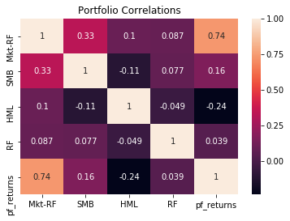

```
Portfolio Correlations:
Mkt-RF    0.738586
SMB       0.162303
RF        0.039383
HML      -0.237647
dtype: float64
```

```python
# Plot the correlation
sns.heatmap(factor_returns.corr(), annot=True)
b, t = plt.ylim()
b += 0.5
t -= 0.5
plt.ylim(b, t)
plt.title('Portfolio Correlations')
plt.show()

# Print the correlations
print('Portfolio Correlations:')
print(factor_returns.drop('pf_returns',axis=1).corrwith(factor_returns.pf_returns).sort_values(ascending=False))
```

# Linear regression model

Here we're going to use the Fama French model to explain the returns in our portfolio. We'll first walk through the linear regression model taking all the different steps, and obtain the summary at the end to interpret the results using **statsmodels**.

```python
import statsmodels.api as sm

# Define the model
model = sm.OLS(factor_returns['pf_returns'], factor_returns[['Mkt-RF','SMB', 'HML']]).fit()

# Create model predictions
predictions = model.predict(factor_returns[['Mkt-RF','SMB', 'HML']])

# Print out the summary
model.summary()
```

OLS Regression Results

| Dep. Variable: | pf_returns | R-squared (uncentered): | 0.657 |
| --- | --- | --- | --- |
| Model: | OLS | Adj. R-squared (uncentered): | 0.653 |
| Method: | Least Squares | F-statistic: | 158.8 |
| Date: | Mon, 11 May 2020 | Prob (F-statistic): | 1.55e-57 |
| Time: | 16:40:45 | Log-Likelihood: | -185.67 |
| No. Observations: | 252 | AIC: | 377.3 |
| Df Residuals: | 249 | BIC: | 387.9 |
| Df Model: | 3 |  |  |
| Covariance Type: | nonrobust |  |  |

|  | coef | std err | t | P>\|t\| | [0.025 | 0.975] |
| --- | --- | --- | --- | --- | --- | --- |
| Mkt-RF | 0.8234 | 0.040 | 20.627 | 0.000 | 0.745 | 0.902 |
| SMB | -0.2272 | 0.064 | -3.545 | 0.000 | -0.353 | -0.101 |
| HML | -0.4826 | 0.056 | -8.611 | 0.000 | -0.593 | -0.372 |

| Omnibus: | 143.224 | Durbin-Watson: | 1.925 |
| --- | --- | --- | --- |
| Prob(Omnibus): | 0.000 | Jarque-Bera (JB): | 1746.552 |
| Skew: | 1.972 | Prob(JB): | 0.00 |
| Kurtosis: | 15.279 | Cond. No. | 1.89 |

Warnings:  
[1] Standard Errors assume that the covariance matrix of the errors is correctly specified.

The market excess returns are positively related to the portfolio returns, and the other two factors SMB and HML are negatively related. They all have a significant effect on the portfolio returns.

## Fama French Factor model

Here we are going focus on efficiently obtaining just the $\beta$ coefficients of the Fama French model. The betas indicate how much of the portfolio's return changes if that particular factor's return changes.

Sometimes, all you want to do is to check whether the factor relates negatively, or positively to your portfolio returns. You can see this directly from the signs of the $\beta$ coefficients.

```python
# Obtain the beta coefficients
b1, b2, b3 = sm.OLS(factor_returns['pf_returns'], factor_returns[['Mkt-RF','SMB', 'HML']]).fit().params

# Print the betas
print ('Sensitivities of active returns to factors:\nMkt-Rf: %f\nSMB: %f\nHML: %f' %  (b1, b2, b3))
```

```
Sensitivities of active returns to factors:
Mkt-Rf: 0.823443
SMB: -0.227198
HML: -0.482598
```

# Portfolio analysis tools

## Pyfolio performance tear sheet

Here we're going to create a full performance tear sheet on the **S&P500** returns. We'll see that the elaborate calculations we've done in previously, we can very quickly generate this simple tear sheet, and by inputting just the returns data. In that sense, this tear sheet can save you a lot of time!

In the first few steps, we'll have to make sure that the data is in the right format otherwise, `Pyfolio` will give an error

```python
import warnings
warnings.filterwarnings('ignore')
```

| Start date End date Total months | 2015-01-05 2019-03-19 50 Backtest | 2015-01-05 2019-03-19 50 |
| --- | --- | --- |
| Annual return | 7.9% |  |
| Cumulative returns | 37.6% |  |
| Annual volatility | 13.7% |  |
| Sharpe ratio | 0.63 |  |
| Calmar ratio | 0.40 |  |
| Stability | 0.85 |  |
| Max drawdown | -19.8% |  |
| Omega ratio | 1.12 |  |
| Sortino ratio | 0.87 |  |
| Skew | -0.38 |  |
| Kurtosis | 3.90 |  |
| Tail ratio | 0.94 |  |
| Daily value at risk | -1.7% |  |

| Worst drawdown periods | Net drawdown in % | Peak date | Valley date | Recovery date | Duration |
| --- | --- | --- | --- | --- | --- |
| 0 | 19.78 | 2018-09-20 | 2018-12-24 | NaT | NaN |
| 1 | 14.16 | 2015-05-21 | 2016-02-11 | 2016-07-11 | 298 |
| 2 | 10.16 | 2018-01-26 | 2018-02-08 | 2018-08-24 | 151 |
| 3 | 4.79 | 2016-08-15 | 2016-11-04 | 2016-11-21 | 71 |
| 4 | 3.64 | 2015-03-02 | 2015-03-11 | 2015-04-24 | 40 |

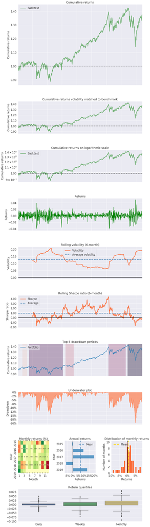

```python
import pyfolio as pf

# Set the index to datetime
returns_sp500.index=pd.to_datetime(returns_sp500.index)

# Ensure the returns are a series
returns = returns_sp500['S&P500']

# Create the returns tear sheet
fig = pf.create_returns_tear_sheet(returns, return_fig=True)
```

# Industry exposures with Pyfolio

Previously we used a `groupby` function to create the active weights per industry. The drawback is that it takes a snapshot in time. Since portfolio weights change, you can imagine that the industry exposures change over time as well. However, the calculation to determine industry exposures on each day for your portfolio, can become quite tedious and complex.

Luckily, you can use `Pyfolio's` tear sheet for this. The tear sheet shows you exposures over time, and summarizes overall top stock picks in your portfolio. Available is data on your portfolio returns under returns, and your daily positions in dollar value per stock, under positions. Go ahead and inspect positions and returns in the console.

| Top 10 long positions of all time | max |
| --- | --- |
| COST | 90.01% |
| DELL | 85.73% |
| CERN | 83.53% |
| MMM | 82.09% |
| INTC | 78.59% |
| AMD | 75.76% |
| GPS | 62.24% |

| Top 10 short positions of all time | max |
| --- | --- |
| AMD | -30.12% |
| DELL | -26.58% |
| CERN | -25.51% |
| MMM | -22.62% |
| GPS | -20.09% |
| INTC | -18.47% |
| COST | -16.44% |

| Top 10 positions of all time | max |
| --- | --- |
| COST | 90.01% |
| DELL | 85.73% |
| CERN | 83.53% |
| MMM | 82.09% |
| INTC | 78.59% |
| AMD | 75.76% |
| GPS | 62.24% |

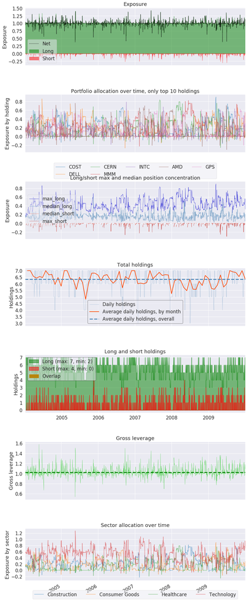

```python
# Load Data
positions = pd.read_csv('test_pos.csv', index_col='index')
returns = pd.read_csv('test_returns.csv', header=None, index_col=0)

# Set the index to datetime
positions.index=pd.to_datetime(positions.index)
returns.index=pd.to_datetime(returns.index)

# Define sector mappings
sect_map = {'COST': 'Consumer Goods',
            'INTC': 'Technology',
            'CERN': 'Healthcare',
            'GPS': 'Technology',
            'MMM': 'Construction',
            'DELL': 'Technology',
            'AMD': 'Technology'}

# Create sector exposure tear sheet
pf.create_position_tear_sheet(returns, positions, sector_mappings=sect_map);
```

# Modern portfolio theory

Modern portfolio theory (MPT) is a theory on how risk-averse investors can construct portfolios to optimize or maximize expected return based on a given level of market risk, emphasizing that risk is an inherent part of higher reward. According to the theory, it's possible to construct an "efficient frontier" of optimal portfolios offering the maximum possible expected return for a given level of risk. This theory was pioneered by **Harry Markowitz** in his paper "Portfolio Selection," published in $1952$ by the Journal of Finance. He was later awarded a Nobel prize for developing the MPT.

## What is Portfolio Optimization?

Portfolio optimization is the process of selecting the best portfolio (asset distribution), out of the set of all portfolios being considered, according to some objective. The objective typically maximizes factors such as expected return, and minimizes costs like financial risk (volatility). Factors being considered may range from tangible (such as assets, liabilities, earnings or other fundamentals) to intangible (such as selective divestment).

- Minimize the portfolio variance, subject to:
- The expected mean return is at least some target return
- The weights sum up to $100\%$
- At least some weights are positive

$$ \underset{w}{\mathrm{minimise}} \: w^T \sum w $$$$ \text{subject} \: \text{to} \: w^T \mu \ge \mu^* $$$$ w^T 1 = 1 $$$$ w_i \ge 0 $$

### Varying target returns leads to the Efficient Frontier

[figure not shown]

# Calculating expected risk and returns

Here we're going to start with the raw price data. What we'll need for portfolio optimization, is the expected risk and return from this data.

With `PyPortfolioOpt`, we can calculate the expected risk and return in just one line of code, so that makes it very easy for you. The library you need is called `pypfopt` in short. FYI, we'll see that `PyPortfolioOpt` gives us the same output if you were to calculate it by hand.

## Load Data

```python
stock_prices = pd.read_csv('https://assets.datacamp.com/production/repositories/4745/datasets/da4863e3ea40482a56929e595f1a7c6e1fdaf614/small_portfolio.csv',
                            index_col = 'date')

stock_prices.head()
```

| date | GE | JPM | MSFT | PG |
| --- | --- | --- | --- | --- |
| 2015-01-02 | 25.06 | 62.49 | 46.760 | 90.44 |
| 2015-01-05 | 24.60 | 60.55 | 46.325 | 90.01 |
| 2015-01-06 | 24.07 | 58.98 | 45.650 | 89.60 |
| 2015-01-07 | 24.08 | 59.07 | 46.230 | 90.07 |
| 2015-01-08 | 24.37 | 60.39 | 47.590 | 91.10 |

```
Mean Return:
MSFT    0.228539
JPM     0.193822
PG     -0.036344
GE     -0.170134
dtype: float64
```

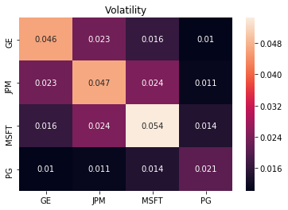

```python
# Import the packages
from pypfopt import risk_models
from pypfopt import expected_returns
from pypfopt.efficient_frontier import EfficientFrontier

# Calculate expected returns mu
mu = expected_returns.mean_historical_return(stock_prices)

# Calculate the covariance matrix S
Sigma = risk_models.sample_cov(stock_prices)

# Obtain the efficient frontier
ef = EfficientFrontier(mu, Sigma)

print('Mean Return:')
print(mu.sort_values(ascending=False))

# Plot the volatility
sns.heatmap(Sigma, annot=True)
b, t = plt.ylim()
b += 0.5
t -= 0.5
plt.ylim(b, t)
plt.title('Volatility')
plt.show()
```

## PyPortfolioOpt risk functions

The objective of the Markowitz portfolio optimization problem is to minimize the portfolio variance, given a bunch of constraints. Remember to calculate this: Portfolio variance = *weights transposed* covariance matrix weights. `WithPyPortfolioOpt` we call the covariance matrix sigma, to denote that this is a sample covariance $\sum$.

Here we will see that the `PyPortfolioOpt` functions to calculate sigma, gives the exact same result if you were to calculate the covariance by hand. The same goes for the expected return calculations, you can also verify PyPortfolioOpt gives the same output as calculating annualized daily returns by hand.

```python
# Get the returns from the stock price data
returns=stock_prices.pct_change()

# Calculate the annualized covariance matrix
covMatrix = returns.cov()*252

# Calculate the covariance matrix Sigma from a`PyPortfolioOpt` function
Sigma = risk_models.sample_cov(stock_prices)

# Print both covariance matrices
print(covMatrix)
print('\n',Sigma)
```

```
            GE       JPM      MSFT        PG
GE    0.046355  0.023011  0.016415  0.010182
JPM   0.023011  0.047033  0.024328  0.010899
MSFT  0.016415  0.024328  0.054486  0.014257
PG    0.010182  0.010899  0.014257  0.020810

             GE       JPM      MSFT        PG
GE    0.046355  0.023011  0.016415  0.010182
JPM   0.023011  0.047033  0.024328  0.010899
MSFT  0.016415  0.024328  0.054486  0.014257
PG    0.010182  0.010899  0.014257  0.020810
```

# Optimal portfolio performance

Let's now continue with the efficient frontier `ef` that we calculated previously for the small portfolio. We still need to select an optimal portfolio from that efficient frontier `ef`, and check its performance. Let's use the `efficient_return` option. This function selects the portfolio with the minimized risk given a target return. A portfolio manager is often asked to manage a portfolio under certain risk and return constraints, so this is a very useful function for that.

```python
# Get the minimum risk portfolio for a target return
weights = ef.efficient_return(0.2)
print(weights)

# Show portfolio performance
ef.portfolio_performance(verbose=True)
```

```
{'GE': 0.0, 'JPM': 0.48580104536633295, 'MSFT': 0.47012826722511836, 'PG': 0.04407068740854872}
Expected annual return: 20.0%
Annual volatility: 18.8%
Sharpe Ratio: 0.96
```

```
(0.19999999999290274, 0.1880234326281461, 0.9573274856059495)
```

By setting the target return of $0.2$, mind you this is $20\%$, you get a mix of three stocks with positive weights in the portfolio.

# Maximum Sharpe vs. minimum volatility

- **Efficient frontier:** all portfolios with an optimal risk and return trade-off
- **Maximum Sharpe portfolio:** the highest Sharpe ratio on the EF
- **Minimum volatility portfolio:** the lowest level of risk on the EF

## Adjusting PyPortfolioOpt optimization

[figure not shown]

# Portfolio optimization: Max Sharpe

Here we're going to calculate the portfolio that gives the Maximum Sharpe ratio. Often, this is the portfolio the investor wants to invest in, as it provides the highest possible return to risk ratio. `PyPortfolioOpt` makes it very easy to calculate this portfolio from a set of historical price data.

```python
# Define the efficient frontier
ef = EfficientFrontier(mu, Sigma)

# Calculate weights for the maximum Sharpe ratio portfolio
raw_weights_maxsharpe = ef.max_sharpe()
cleaned_weights_maxsharpe = ef.clean_weights()

print('Raw weights:')
print(raw_weights_maxsharpe)
print('\nCleaned weights:')
print(cleaned_weights_maxsharpe)
```

```
Raw weights:
{'GE': 1.8445997089162845e-16, 'JPM': 0.44136825124020784, 'MSFT': 0.558631748759792, 'PG': 0.0}

Cleaned weights:
{'GE': 0.0, 'JPM': 0.44137, 'MSFT': 0.55863, 'PG': 0.0}
```

## Minimum volatility optimization

Here we're going to compare the minimum volatility and the Maximum Sharpe portfolios. As a portfolio manager you often want to understand how your chosen portfolio measures up to the minimum volatility portfolio. With `PyPortfolioOpt` you can compare the two quickly, without having to write two different constrained optimization problems, which can be quite complex.

```python
# Calculate weights for the maximum Sharpe ratio portfolio
raw_weights_maxsharpe = ef.max_sharpe()
cleaned_weights_maxsharpe = ef.clean_weights()

# Show portfolio performance
print('Max Sharpe:')
print(cleaned_weights_maxsharpe)
ef.portfolio_performance(verbose=True)
```

```
Max Sharpe:
{'GE': 0.0, 'JPM': 0.44137, 'MSFT': 0.55863, 'PG': 0.0}
Expected annual return: 21.3%
Annual volatility: 19.5%
Sharpe Ratio: 0.99
```

```
(0.2132161312005243, 0.19535212189989304, 0.9890659457466077)
```

```python
# Calculate weights for the minimum volatility portfolio
raw_weights_minvol = ef.min_volatility()
cleaned_weights_minvol = ef.clean_weights()

# Show portfolio performance
print('Min volatility:')
print(cleaned_weights_minvol)
ef.portfolio_performance(verbose=True)
```

```
Min volatility:
{'GE': 0.15825, 'JPM': 0.11004, 'MSFT': 0.05305, 'PG': 0.67865}
Expected annual return: -1.8%
Annual volatility: 13.3%
Sharpe Ratio: -0.29
```

```
(-0.018136397146806496, 0.13293210141744938, -0.286886288113704)
```

The min vol portfolio has a lower performance but lower risk, since all stocks have a positive weight in the min vol portfolio and some stocks have a negative expected return.

# Alternative portfolio optimization

## Expected risk and return based on historic data

- Mean historic returns, or the historic portfolio variance are not perfect estimates of mu and Sigma
- Weights from portfolio optimization therefore **not guaranteed to work well** on future data

### Exponentially weighted returns

- Need better measures for risk and return
- Exponentially weighted risk and return assigns more importance to the most recent data
- Exponential moving average in the graph: most weight on $t-1$ observation

[figure not shown]

### Exponentially weighted covariance

- The exponential covariance matrix: gives more weight to recent data
- In the graph: exponential weighted volatility in black, follows real volatility better than standard volatility in blue

[figure not shown]

# Exponentially weighted returns and risk

Here we're going to perform portfolio optimization with a slightly different way of estimating risk and returns; we're going to give more weight to recent data in the optimization. This is a smart way to deal with stock data that is typically non-stationary, i.e., when the distribution changes over time. Implementation can be quickly done by changing the risk model you use to calculate `Sigma`, and the returns calculation you use to get `mu`.

```python
# Define exponentially weighted Sigma and mu
Sigma = risk_models.exp_cov(stock_prices, span=180, frequency=252)
mu = expected_returns.ema_historical_return(stock_prices, frequency=252, span=180)

# Calculate the efficient frontier
ef = EfficientFrontier(mu, Sigma)

# Calculate weights for the maximum sharpe ratio optimization
raw_weights_maxsharpe = ef.max_sharpe()

# Show portfolio performance
ef.portfolio_performance(verbose=True)
```

```
Expected annual return: 23.4%
Annual volatility: 23.8%
Sharpe Ratio: 0.90
```

```
(0.23383227825070665, 0.2382793231662429, 0.8974017359513817)
```

In this setting you used observations from more recent data to weigh more heavily in your decision, which is especially interesting if you're managing a trend following portfolio.

## Changing the span

Previously we discovered that the span of the exponentially weighted risk and return can have an impact on what the optimal portfolio looks like. In fact, the span has a very big influence! By setting the span, you can either use data for say only the most recent days, or use data from the most recent years. In the limit, when the span is as long as the full sample, it will be equal to using the normal historic mean.

Change the span to $2$ years, and see how that changes your optimal portfolio.

```python
# Calculate expected returns and sample covariance
mu_ema = expected_returns.ema_historical_return(stock_prices, span=252*2 ,frequency=252)
Sigma_ew = risk_models.exp_cov(stock_prices, span=252*2, frequency=252)
ef_2 = EfficientFrontier(mu_ema, Sigma_ew)

# Calculate weights for the maximum Sharpe ratio portfolio
weights = ef_2.max_sharpe()
cleaned_weights_maxsharpe_EW = ef_2.clean_weights()
perf_max_sharpe_EW = ef_2.portfolio_performance(verbose=True)
```

```
Expected annual return: 26.4%
Annual volatility: 18.5%
Sharpe Ratio: 1.32
```

Change the span to $10$ days, and see how that changes your optimal portfolio.

```python
# Calculate expected returns and sample covariance
mu_ema = expected_returns.ema_historical_return(stock_prices, span=10 ,frequency=252)
Sigma_ew = risk_models.exp_cov(stock_prices, span=10, frequency=252)
ef_2 = EfficientFrontier(mu_ema, Sigma_ew)

# Calculate weights for the maximum Sharpe ratio portfolio
weights = ef_2.max_sharpe()
cleaned_weights_maxsharpe_EW = ef_2.clean_weights()
perf_max_sharpe_EW = ef_2.portfolio_performance(verbose=True)
```

```
Expected annual return: 12.1%
Annual volatility: 17.0%
Sharpe Ratio: 0.59
```

Interesting isn't it, that by playing around with the span, you get two completely different type of portfolios, each with a very different Sharpe ratio. If your data is very volatile and changes rapidly, working with a short span might give you better predictive power of the expected return, with a faster moving investment strategy. However, if your data is rather slow moving as is the case with this data, the short span does not help you in better predicting expected risk and returns.